# 2주차 패키지

통계학과 2019313106 홍현경

2021년 3월 18일

## Chapter 1. 모델링을 위한 전처리

### 문제 0. 기본 세팅

- Chapter 1에서 쓸 패키지인 tidyverse, data.table, VIM을 불러옵니다.

```r
library(tidyverse)
library(data.table)
library(VIM)
```

- 읽어들일 파일이 있는 위치로 경로를 설정합니다.

```r
setwd("/Users/hyungyeonghong/Desktop/P-Sat/week2/week2_package")
```

- Working directory 설정까지 완료하였으니 이제 사용할 데이터를 불러옵니다.

```r
data <- fread("data.csv")
```

- 부가적으로, dim()을 이용하여 변수의 개수와 관찰값의 개수를 확인하고, str()을 이용하여 불러온 데이터가 가진 변수들을 확인하겠습니다.

```r
# checking the dimension
data %>% dim
```

```
## [1] 301  43
```

```r
# checking the structure
data %>% str
```

```
## Classes 'data.table' and 'data.frame':   301 obs. of  43 variables:
##  $ OC             : chr  "open" "open" "open" "open" ...
##  $ bedCount       : int  175 410 468 353 196 243 213 250 280 55 ...
##  $ revenue1       : num  4.22e+09 NA 1.00e+09 7.25e+10 4.90e+10 ...
##  $ salescost1     : num  0.00 NA 5.15e+08 0.00 0.00 ...
##  $ sga1           : num  3.96e+09 NA 4.47e+08 7.07e+10 4.77e+10 ...
##  $ salary1        : num  2.03e+09 NA 2.96e+08 3.18e+10 2.45e+10 ...
##  $ noi1           :integer64 15652441 NA 76156 506223059 112352259 65414325 305646045 1426186507 ...
##  $ noe1           :integer64 15236236 NA 30000 1259567512 1419089382 741269419 970008848 3166922895 ...
##  $ interest1      :integer64 13236236 NA 0 1196881219 1307248652 336462245 940942802 465983760 ...
##  $ ctax1          :integer64 31641798 NA 0 173769780 0 0 0 524566650 ...
##  $ profit1        :integer64 225169678 NA 41864754 902830288 80749696 -46227375 864530415 453318139 ...
##  $ liquidAsset1   :integer64 1012699685 NA 272442138 13041543085 6317084032 5635104883 11407504260 12756514354 ...
##  $ quickAsset1    :integer64 997671878 NA 253682170 11534749645 5873265455 5481680248 11236305651 11879215739 ...
##  $ receivableS1   : num  4.7e+08 NA 8.1e+06 0.0 4.1e+09 ...
```

[output cut: 30 more lines]

총 43개의 변수와 301개의 관찰값이 있는 것을 확인할 수 있습니다.

### 문제 1. ’2’로 끝나는 변수 모두 제거

- contains()와 ends_with()를 이용하여 ’2’로 끝나는 변수들을 제외한 나머지 변수들만 뽑아내어 data에 저장합니다.

```r
data <- data %>% select(-ends_with("2"))
```

- dim()을 이용하여 변수가 제거되었는지 확인합니다.

```r
data %>% dim
```

```
## [1] 301  23
```

- str()을 이용하여 ’2’로 끝나는 변수들이 모두 삭제되었는지 최종적으로 확인하겠습니다.

```r
data %>% str
```

```
## Classes 'data.table' and 'data.frame':   301 obs. of  23 variables:
##  $ OC             : chr  "open" "open" "open" "open" ...
##  $ bedCount       : int  175 410 468 353 196 243 213 250 280 55 ...
##  $ revenue1       : num  4.22e+09 NA 1.00e+09 7.25e+10 4.90e+10 ...
##  $ salescost1     : num  0.00 NA 5.15e+08 0.00 0.00 ...
##  $ sga1           : num  3.96e+09 NA 4.47e+08 7.07e+10 4.77e+10 ...
##  $ salary1        : num  2.03e+09 NA 2.96e+08 3.18e+10 2.45e+10 ...
##  $ noi1           :integer64 15652441 NA 76156 506223059 112352259 65414325 305646045 1426186507 ...
##  $ noe1           :integer64 15236236 NA 30000 1259567512 1419089382 741269419 970008848 3166922895 ...
##  $ interest1      :integer64 13236236 NA 0 1196881219 1307248652 336462245 940942802 465983760 ...
##  $ ctax1          :integer64 31641798 NA 0 173769780 0 0 0 524566650 ...
##  $ profit1        :integer64 225169678 NA 41864754 902830288 80749696 -46227375 864530415 453318139 ...
##  $ liquidAsset1   :integer64 1012699685 NA 272442138 13041543085 6317084032 5635104883 11407504260 12756514354 ...
##  $ quickAsset1    :integer64 997671878 NA 253682170 11534749645 5873265455 5481680248 11236305651 11879215739 ...
##  $ receivableS1   : num  4.7e+08 NA 8.1e+06 0.0 4.1e+09 ...
##  $ inventoryAsset1: int  15027807 NA 18759968 1506793440 443818577 153424635 171198609 877298615 15177723 615660150 ...
##  $ nonCAsset1     : num  2.51e+09 NA 1.20e+08 4.32e+10 4.37e+10 ...
##  $ tanAsset1      : num  2.36e+09 NA 1.20e+08 3.83e+10 4.33e+10 ...
##  $ OnonCAsset1    : num  1.43e+08 NA 0.00 3.95e+09 2.22e+08 ...
##  $ receivableL1   : int  0 NA 0 0 0 0 0 0 0 0 ...
##  $ debt1          :integer64 682825991 NA 92414342 42363797762 49898105519 0 24122304855 46886016081 ...
##  $ surplus1       : num  1.50e+09 NA 0.00 8.64e+09 9.03e+09 ...
##  $ employee1      : int  62 801 234 663 206 397 221 489 243 370 ...
##  $ ownerChange    : chr  "same" "same" "same" "same" ...
##  - attr(*, ".internal.selfref")=<externalptr>
```

문제 0에서 확인한 str()의 결과와는 달리 ’2’로 끝나는 변수들이 모두 삭제된 것을 확인할 수 있습니다.

### 문제 2. ’VIM’패키지를 이용하여 data 시각화

VIM 패키지를 이용하면 missing/imputed values를 시각화할 수 있습니다. VIM 패키지를 이용하여 data의 missing/imputed values를 확인해보겠습니다.

- missing/imputed values를 시각화하여 확인하기 위해 VIM 패키지의 aggr() 함수를 이용합니다.
  - col=c(“lightyellow”,“pink”): 결측 값이 없는 셀의 색을 lightyellow, 결측 값이 있는 셀의 색깔을 pink로 변경합니다.
  - numbers=TRUE: 결측 값의 개수를 숫자로 출력합니다.
  - prop=FALSE: 비율이 아닌 빈도로 출력합니다. (prop=TRUE이면 비율로 출력)
  - cex.lab=0.7: 라벨의 글자 크기를 0.7로 조정합니다.
  - cex.axis=0.5: 축에 붙은 변수명의 글자 크기를 0.5로 조정합니다.
  - cex.numbers=0.7: 그래프의 우측에 붙은 numbers의 글자 크기를 0.7로 조정합니다.

```r
data %>% aggr(col=c("lightyellow","pink"), numbers=TRUE, prop=FALSE, cex.lab=0.7, cex.axis=0.5, cex.numbers=0.7)
```

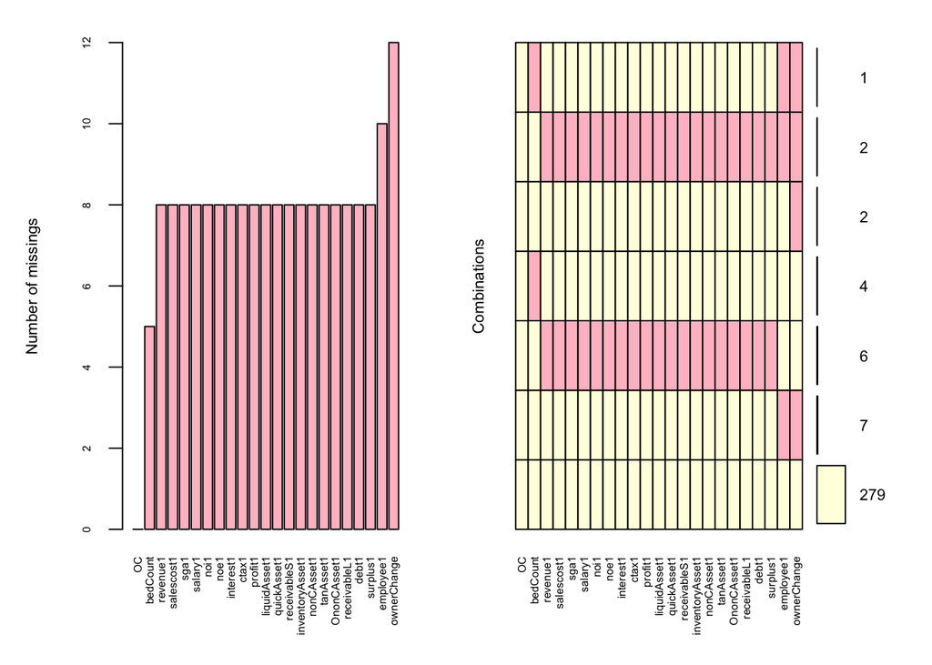

### 문제 3-1. NA imputatuon: 숫자 데이터의 NA값을 mean imputation을 통해 채우기

mean imputation은 특정 변수의 결측치를 해당 변수의 결측치를 제외한 값의 mean으로 대체합니다.

- replace_na(., lapply(., mean, na.rm=TRUE)): tidyr의 replace_na()를 이용하여 결측치를 대체합니다. 이떄, .에 해당하는 부분은 data입니다. 리스트의 각 원소들은 순서대로 각 변수의 결측치를 대체합니다.
- 현재 data에는 범주형 데이터 역시 존재하기 때문에 해당 코드 실행시 argument is not numeric or logical: returning NAargument is not numeric or logical: returning NA라는 메시지가 함께 출력됩니다. 그러나 NA값에 다시 NA가 들어간 것이기 때문에 따로 처리를 하지는 않았습니다.

```r
data <- data %>% replace_na(., lapply(., mean, na.rm=TRUE))
```

- 숫자 데이터의 mean imputation 결과를 확인합니다.
- is.na()를 lapply()를 통해 각 변수에 적용하여 NA값 해당 여부를 TRUE/FALSE로 확인합니다. TRUE == 1, FALSE == 0이므로 lapply(is.na) 결과의 각 변수별로 sapply()를 통해 sum()을 적용한 결과가 0이면 NA값이 모두 채워진 것입니다.
- sapply()를 이용하여 sum()의 결과를 벡터로 출력함으로써 결과를 한눈에 알아보기 쉽도록 하였습니다.

```r
data %>% lapply(is.na) %>% sapply(sum)
```

```
##              OC        bedCount        revenue1      salescost1            sga1
##               0               0               0               0               0
##         salary1            noi1            noe1       interest1           ctax1
##               0               0               0               0               0
##         profit1    liquidAsset1     quickAsset1    receivableS1 inventoryAsset1
##               0               0               0               0               0
##      nonCAsset1       tanAsset1     OnonCAsset1    receivableL1           debt1
##               0               0               0               0               0
##        surplus1       employee1     ownerChange
##               0               0              12
```

범주형 데이터인ownerChange를 제외한 각 변수의 합산 결과가 0인 것으로 보아 숫자 데이터의 결측치가 모두 채워졌음을 알 수 있습니다.

### 문제 3-2. NA imputatuion: 범주 데이터의 NA값을 mode imputation을 통해 채우기

mode imputation은 특정 변수의 결측치를 해당 변수의 최빈값(mode)으로 대체합니다.

- 앞의 결과로부터 범주형 데이터인 ownerChange 변수에 12개의 결측치가 있음을 알 수 있습니다.
- 따라서 이 문제에서는 ownerChange 변수의 결측치를 처리하도록 하겠습니다.
- table %>% which.max %>% labels: 범주형 데이터의 테이블을 이용하여 최빈값의 라벨 리스트를 뽑아냅니다.
- replace_na(data$ownerChange, .): tidyr의 replace_na()를 이용하여 결측치를 대체합니다. 이떄, .에 해당하는 부분은 table %>% which.max %>% labels에서 나온 최빈값 라벨 리스트입니다.

```r
data$ownerChange <- data$ownerChange %>% table %>% which.max %>% labels %>% replace_na(data$ownerChange, .)
```

- 범주형 데이터의 mode imputation 결과를 확인합니다.
- is.na()를 lapply()를 통해 각 변수에 적용하여 NA값 해당 여부를 TRUE/FALSE로 확인합니다. TRUE == 1, FALSE == 0이므로 lapply(is.na) 결과의 각 변수별로 sapply()를 통해 sum()을 적용한 결과가 0이면 NA값이 모두 채워진 것입니다.
- sapply()를 이용하여 sum()의 결과를 벡터로 출력함으로써 결과를 한눈에 알아보기 쉽도록 하였습니다.

```r
data %>% lapply(is.na) %>% sapply(sum)
```

```
##              OC        bedCount        revenue1      salescost1            sga1
##               0               0               0               0               0
##         salary1            noi1            noe1       interest1           ctax1
##               0               0               0               0               0
##         profit1    liquidAsset1     quickAsset1    receivableS1 inventoryAsset1
##               0               0               0               0               0
##      nonCAsset1       tanAsset1     OnonCAsset1    receivableL1           debt1
##               0               0               0               0               0
##        surplus1       employee1     ownerChange
##               0               0               0
```

각 변수의 합산 결과가 0인 것으로 보아 숫자 데이터의 결측치가 모두 채워졌음을 알 수 있습니다. 범주형 변수로 이번 문제의 변환 대상이었던 ownerChange 변수 역시 결측치가 모두 채워졌음을 알 수 있습니다.

### 문제 4. 변수 OC의 “open”을 1, “close”를 0으로 바꾸기

- dplyr 패키지의 recode()를 이용하여 변수 OC의 “open”을 1, “close”를 0으로 바꾸었습니다.

```r
data$OC <- recode(data$OC, "open"=1, "close"=0)
data$OC # 값이 바뀌었는지 확인합니다.
```

```
##   [1] 1 1 1 1 1 1 1 1 1 1 1 1 1 1 1 1 1 1 1 1 1 1 1 1 1 1 1 1 1 1 1 1 1 1 1 0 1
##  [38] 1 1 1 1 1 1 1 1 1 1 1 1 1 1 1 1 1 1 1 1 1 1 1 1 1 1 1 1 1 1 1 1 1 1 0 1 1
##  [75] 1 1 1 1 1 1 1 1 1 1 1 1 1 1 1 1 1 1 1 0 1 1 1 1 1 1 1 1 1 1 1 1 1 1 1 1 1
## [112] 0 1 1 1 1 1 1 1 1 1 1 1 1 1 1 1 1 1 1 1 1 1 1 1 1 1 1 1 1 1 0 1 1 1 1 1 1
## [149] 1 1 1 1 1 1 1 1 1 1 0 1 1 1 1 1 1 1 1 1 1 1 1 1 1 1 1 1 1 0 1 1 1 1 1 1 1
## [186] 1 1 1 1 1 1 1 1 0 1 1 1 1 1 1 1 1 1 1 1 1 1 1 1 1 1 1 0 1 0 1 1 1 1 1 1 1
## [223] 1 1 1 1 1 1 1 1 1 1 1 1 1 1 1 1 1 1 1 1 1 1 1 1 1 1 1 1 1 1 1 1 1 1 1 1 1
## [260] 1 1 0 1 1 1 1 1 1 1 1 1 1 1 1 1 1 1 1 1 1 1 1 1 1 1 1 1 1 1 1 0 1 1 1 1 1
## [297] 1 0 0 0 1
```

“open”=1, “close”=0으로 변환이 되었음을 확인할 수 있습니다.

### 문제 5. 숫자 데이터 중 integer 자료형을 numeric 자료형으로 바꾸기

- ownerChange를 제외한 나머지 변수를 추출한 후 numeric으로 변환합니다. 이후 dplyr의 bind_cols()를 이용하여 기존의 범주형 데이터인 ownerChange를 합쳐줍니다.

```r
data <- data[,c(1:22)] %>% lapply(as.numeric) %>% bind_cols(.,ownerChange = data$ownerChange)
data %>% str # 변환이 제대로 되었는지 확인합니다.
```

```
## tibble [301 × 23] (S3: tbl_df/tbl/data.frame)
##  $ OC             : num [1:301] 1 1 1 1 1 1 1 1 1 1 ...
##  $ bedCount       : num [1:301] 175 410 468 353 196 243 213 250 280 55 ...
##  $ revenue1       : num [1:301] 4.22e+09 1.29e+10 1.00e+09 7.25e+10 4.90e+10 ...
##  $ salescost1     : num [1:301] 0.00 2.01e+09 5.15e+08 0.00 0.00 ...
##  $ sga1           : num [1:301] 3.96e+09 1.03e+10 4.47e+08 7.07e+10 4.77e+10 ...
##  $ salary1        : num [1:301] 2.03e+09 5.65e+09 2.96e+08 3.18e+10 2.45e+10 ...
##  $ noi1           : num [1:301] 1.57e+07 2.70e+08 7.62e+04 5.06e+08 1.12e+08 ...
##  $ noe1           : num [1:301] 1.52e+07 5.12e+08 3.00e+04 1.26e+09 1.42e+09 ...
##  $ interest1      : num [1:301] 1.32e+07 1.87e+08 0.00 1.20e+09 1.31e+09 ...
##  $ ctax1          : num [1:301] 3.16e+07 7.85e+07 0.00 1.74e+08 0.00 ...
##  $ profit1        : num [1:301] 2.25e+08 2.10e+08 4.19e+07 9.03e+08 8.07e+07 ...
##  $ liquidAsset1   : num [1:301] 1.01e+09 3.54e+09 2.72e+08 1.30e+10 6.32e+09 ...
##  $ quickAsset1    : num [1:301] 9.98e+08 3.41e+09 2.54e+08 1.15e+10 5.87e+09 ...
##  $ receivableS1   : num [1:301] 4.70e+08 6.98e+08 8.10e+06 0.00 4.10e+09 ...
##  $ inventoryAsset1: num [1:301] 1.50e+07 1.15e+08 1.88e+07 1.51e+09 4.44e+08 ...
##  $ nonCAsset1     : num [1:301] 2.51e+09 1.14e+10 1.20e+08 4.32e+10 4.37e+10 ...
##  $ tanAsset1      : num [1:301] 2.36e+09 1.05e+10 1.20e+08 3.83e+10 4.33e+10 ...
##  $ OnonCAsset1    : num [1:301] 1.43e+08 3.41e+08 0.00 3.95e+09 2.22e+08 ...
##  $ receivableL1   : num [1:301] 0 251680 0 0 0 ...
##  $ debt1          : num [1:301] 6.83e+08 8.77e+09 9.24e+07 4.24e+10 4.99e+10 ...
##  $ surplus1       : num [1:301] 1.50e+09 1.27e+09 0.00 8.64e+09 9.03e+09 ...
##  $ employee1      : num [1:301] 62 801 234 663 206 397 221 489 243 370 ...
##  $ ownerChange    : chr [1:301] "same" "same" "same" "same" ...
```

ownerChange를 제외한 나머지 변수가 num인 것을 확인할 수 있습니다.

## Chapter 2. 분류모델

## [모델 1] 로지스틱 회귀

### 문제 1. 전처리한 데이터를 train과 validation set으로 나누기

```r
library(caret)
library(MLmetrics)
library(randomForest)
```

- createDataPartition을 이용하여 데이터를 train과 validation set으로 나눕니다.
- 로지스틱 회귀의 종속 변수는 범주형 데이터이고, 두 개의 possible outcomes를 가집니다. 따라서 타겟 변수는 OC로 설정합니다.

```r
set.seed(1234)

train_idx <- createDataPartition(data$OC, p=0.3, list=FALSE)
train_data <- data[-train_idx,]
valid_data <- data[train_idx,]
```

### 문제 2. train 데이터의 모든 변수를 이용하여 OC를 타겟으로 하는 로지스틱 회귀를 만들고 validation set의 accuracy 구하기

- 우선, 로지스틱 회귀 모형을 만드는 glm()을 이용하여 로지스틱 회귀 모형을 fit 합니다.
- 로지스틱 회귀 모형 추정에는 train데이터를 이용하며, 타겟 변수는 OC입니다.

```r
logit_fit <- glm(formula=OC~., data=train_data, family=binomial)
summary(logit_fit)
```

```
##
## Call:
## glm(formula = OC ~ ., family = binomial, data = train_data)
##
## Deviance Residuals:
##      Min        1Q    Median        3Q       Max
## -2.65580   0.00001   0.01373   0.11327   1.39761
##
## Coefficients:
##                   Estimate Std. Error z value Pr(>|z|)
## (Intercept)      2.092e+00  1.209e+00   1.731   0.0835 .
## bedCount        -5.748e-03  1.042e-02  -0.552   0.5812
## revenue1        -7.791e-07  1.151e-05  -0.068   0.9461
## salescost1       7.785e-07  1.151e-05   0.068   0.9461
## sga1             7.814e-07  1.151e-05   0.068   0.9459
## salary1         -1.858e-09  2.556e-09  -0.727   0.4673
## noi1            -7.838e-07  1.151e-05  -0.068   0.9457
## noe1             7.790e-07  1.151e-05   0.068   0.9461
## interest1       -8.830e-09  6.279e-09  -1.406   0.1596
## ctax1            7.806e-07  1.151e-05   0.068   0.9459
## profit1          7.788e-07  1.151e-05   0.068   0.9461
## liquidAsset1     7.908e-08  1.262e-07   0.626   0.5311
## quickAsset1     -8.027e-08  1.263e-07  -0.636   0.5250
## receivableS1    -1.296e-09  7.712e-10  -1.681   0.0928 .
## inventoryAsset1 -9.233e-08  1.295e-07  -0.713   0.4758
## nonCAsset1       2.518e-08  2.445e-08   1.030   0.3031
## tanAsset1       -2.516e-08  2.450e-08  -1.027   0.3046
## OnonCAsset1     -9.350e-09  2.979e-08  -0.314   0.7536
## receivableL1    -2.760e-06  5.623e-05  -0.049   0.9609
## debt1            1.693e-11  3.092e-10   0.055   0.9563
## surplus1         1.087e-10  5.432e-10   0.200   0.8414
## employee1        3.970e-03  1.539e-02   0.258   0.7964
## ownerChangesame  2.216e+00  1.568e+00   1.413   0.1576
## ---
## Signif. codes:  0 '***' 0.001 '**' 0.01 '*' 0.05 '.' 0.1 ' ' 1
##
## (Dispersion parameter for binomial family taken to be 1)
##
##     Null deviance: 74.307  on 209  degrees of freedom
## Residual deviance: 28.953  on 187  degrees of freedom
## AIC: 74.953
##
## Number of Fisher Scoring iterations: 16
```

- fit한 로지스틱 회귀모형을 validation set을 이용하여 평가합니다.
- fit한 로지스틱 회귀모형을 이용하여 예측한 값이 0.5 이상이면 1, 0.5 미만이면 0을 부여합니다.
- 이를 바탕으로 validation set의 예측값과 실제값을 바탕으로 MLmetrics의 Accuracy()를 이용하여 accuracy를 측정합니다.

```r
logit_predict <- predict(logit_fit, valid_data, type="response")
predict_true <- ifelse(logit_predict >= 0.5, 1, 0)
Accuracy(predict_true, valid_data$OC) # accuracy 값을 구합니다.
```

```
## [1] 0.9120879
```

### 문제 3. 단계적 선택법을 이용하여 변수를 선택한 후 로지스틱 회귀 모형 만들고 validation set 이용하여 accuracy 구하기

- 앞 문제에서 구한 회귀모형에 step()을 적용하여 변구를 선택합니다.
- AIC 값이 가장 작은 변수의 조합을 선택합니다.

```r
var_select <- step(logit_fit, direction="both")
```

```
## Start:  AIC=74.95
## OC ~ bedCount + revenue1 + salescost1 + sga1 + salary1 + noi1 +
##     noe1 + interest1 + ctax1 + profit1 + liquidAsset1 + quickAsset1 +
##     receivableS1 + inventoryAsset1 + nonCAsset1 + tanAsset1 +
##     OnonCAsset1 + receivableL1 + debt1 + surplus1 + employee1 +
##     ownerChange
##
##                   Df Deviance    AIC
## - ctax1            1   28.953 72.953
## - salescost1       1   28.953 72.953
## - revenue1         1   28.953 72.953
## - sga1             1   28.953 72.953
## - profit1          1   28.953 72.953
## - noi1             1   28.953 72.953
## - noe1             1   28.953 72.953
## - debt1            1   28.956 72.956
## - surplus1         1   28.993 72.993
## - employee1        1   29.027 73.027
## - OnonCAsset1      1   29.059 73.059
## - bedCount         1   29.280 73.280
## - salary1          1   29.482 73.482
## - liquidAsset1     1   29.696 73.696
## - quickAsset1      1   29.779 73.779
## - inventoryAsset1  1   30.373 74.373
## - tanAsset1        1   30.777 74.777
## - nonCAsset1       1   30.791 74.791
## - interest1        1   30.834 74.834
## - receivableL1     1   30.848 74.848
## <none>                 28.953 74.953
## - ownerChange      1   31.231 75.231
## - receivableS1     1   32.724 76.724
##
## Step:  AIC=72.95
## OC ~ bedCount + revenue1 + salescost1 + sga1 + salary1 + noi1 +
##     noe1 + interest1 + profit1 + liquidAsset1 + quickAsset1 +
##     receivableS1 + inventoryAsset1 + nonCAsset1 + tanAsset1 +
##     OnonCAsset1 + receivableL1 + debt1 + surplus1 + employee1 +
##     ownerChange
##
##                   Df Deviance    AIC
```

[output cut: 341 more lines]

```
## + inventoryAsset1  1   33.288 57.288
## + noe1             1   33.503 57.503
## + liquidAsset1     1   33.639 57.639
## + surplus1         1   33.648 57.648
## + salary1          1   33.730 57.730
## + ctax1            1   33.750 57.750
## + OnonCAsset1      1   33.778 57.778
## - noi1             1   37.849 57.849
## - receivableS1     1   41.989 61.989
## - salescost1       1   43.897 63.897
## - tanAsset1        1   44.764 64.764
## - nonCAsset1       1   44.912 64.912
## - receivableL1     1   45.647 65.647
## - quickAsset1      1   46.898 66.898
## - revenue1         1   47.877 67.877
```

```r
formula_select <- formula(var_select)
```

따라서, 최소의 AIC를 가지는 조합인 OC ~ revenue1 + salescost1 + noi1 + interest1 + quickAsset1 + receivableS1 + nonCAsset1 + tanAsset1 + receivableL1 + ownerChange를 이용합니다.

- 단계적선택법을 이용하여 선택한 변수들을 이용하여 로지스틱 회귀모형을 다시 fit 합니다. 역시 training set을 이용합니다

```r
logit_refit <- glm(formula_select, data=train_data, family="binomial")
summary(logit_refit)
```

```
##
## Call:
## glm(formula = formula_select, family = "binomial", data = train_data)
##
## Deviance Residuals:
##      Min        1Q    Median        3Q       Max
## -2.62555   0.00016   0.02839   0.14686   1.39850
##
## Coefficients:
##                   Estimate Std. Error z value Pr(>|z|)
## (Intercept)      2.162e+00  9.377e-01   2.305  0.02114 *
## revenue1         6.986e-10  2.796e-10   2.498  0.01248 *
## salescost1      -1.151e-09  4.074e-10  -2.825  0.00473 **
## noi1            -2.777e-09  1.038e-09  -2.676  0.00746 **
## interest1       -5.215e-09  3.245e-09  -1.607  0.10807
## quickAsset1     -1.034e-09  3.596e-10  -2.876  0.00403 **
## receivableS1    -1.456e-09  5.804e-10  -2.509  0.01210 *
## nonCAsset1       1.662e-08  6.892e-09   2.411  0.01589 *
## tanAsset1       -1.658e-08  6.888e-09  -2.407  0.01606 *
## receivableL1    -1.888e-06  3.343e-05  -0.056  0.95497
## ownerChangesame  2.167e+00  1.316e+00   1.646  0.09968 .
## ---
## Signif. codes:  0 '***' 0.001 '**' 0.01 '*' 0.05 '.' 0.1 ' ' 1
##
## (Dispersion parameter for binomial family taken to be 1)
##
##     Null deviance: 74.307  on 209  degrees of freedom
## Residual deviance: 33.778  on 199  degrees of freedom
## AIC: 55.778
##
## Number of Fisher Scoring iterations: 15
```

- 다시 fit한 로지스틱 회귀모형을 validation set을 이용하여 평가합니다.
- 다시 fit한 로지스틱 회귀모형을 이용하여 예측한 값이 0.5 이상이면 1, 0.5 미만이면 0을 부여합니다.
- 이를 바탕으로 validation set의 예측값과 실제값을 바탕으로 MLmetrics의 Accuracy()를 이용하여 accuracy를 측정합니다.

```r
logit_repredict <- predict(logit_refit, valid_data, type="response")
repredict_true <- ifelse(logit_repredict >= 0.5, 1, 0)
Accuracy(repredict_true, valid_data$OC)
```

```
## [1] 0.9340659
```

accuracy가 이전에 비해 오른 것을 확인할 수 있습니다.

## [모델 2] 랜덤포레스트

### 문제 4. mtry에 대한 그리드서치를 위해 expand.grid를 이용하여 데이터프레임 만들기

- 문제에서 주어진대로 mtry는 3:5, acc는 NA로 설정합니다.

```r
acc_rf <- expand.grid(mtry=3:5, acc=NA); acc_rf
```

```
##   mtry acc
## 1    3  NA
## 2    4  NA
## 3    5  NA
```

### 문제 5. 로지스틱회귀에서 선택된 변수들로 랜덤포레스트에 대한 5-fold 그리드서치를 진행, acc_rf의 acc변수에 해당 Accuracy값 넣기

- caret 패키지의 createFolds()를 이용하여 전체 데이터를 5개로 나눕니다.

```r
set.seed(1234)

num <- vector(mode="numeric", length=5)

for (i in 1:3){
  for (j in 1:5){
    folds <-createFolds(train_data$OC, k=5, list=TRUE)
    test_idx<-folds[[j]]
    cv_train_data <- train_data[-test_idx,]
    cv_test_data <- train_data[test_idx,]
    rf_fit <- randomForest(formula_select, data=cv_train_data, mtry=acc_rf[i,1], ntree=10)
    prediction <- predict(rf_fit,cv_test_data)
    predict_true <- ifelse(prediction >= 0.5, 1, 0)
    num[j] <- Accuracy(predict_true, cv_test_data$OC)
  }
  acc_rf$acc[i]<-mean(num)
}

acc_rf
```

```
##   mtry       acc
## 1    3 0.9571429
## 2    4 0.9666667
## 3    5 0.9523810
```

### 문제 6. acc_rf에서 가장 높은 Accuracy값의 행 출력

```r
acc_rf[which.max(acc_rf$acc), ]
```

```
##   mtry       acc
## 2    4 0.9666667
```

### 문제 7. 가장 좋은 파라미터 조합으로 랜덤포레스트 모델을 학습시킨 후 varlmPlot과 ggplot을 이용해 시각화하기

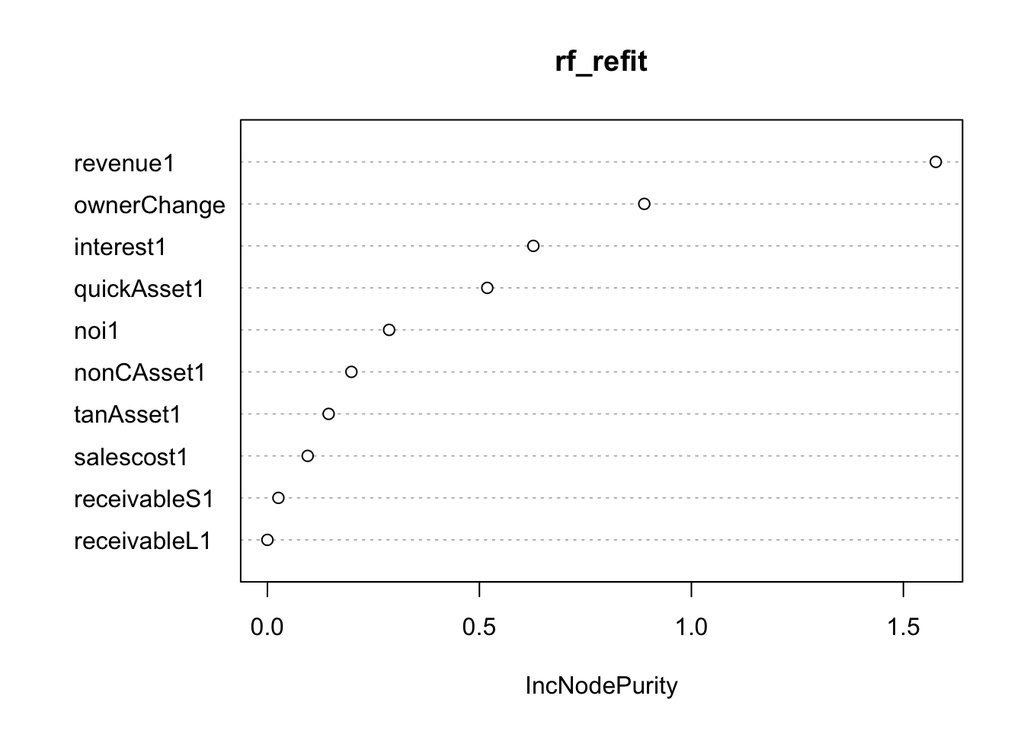

```r
set.seed(1234)

rf_refit <- randomForest(formula_select, data=valid_data, mtry=4, ntree=10)
varImpPlot(rf_refit)
```

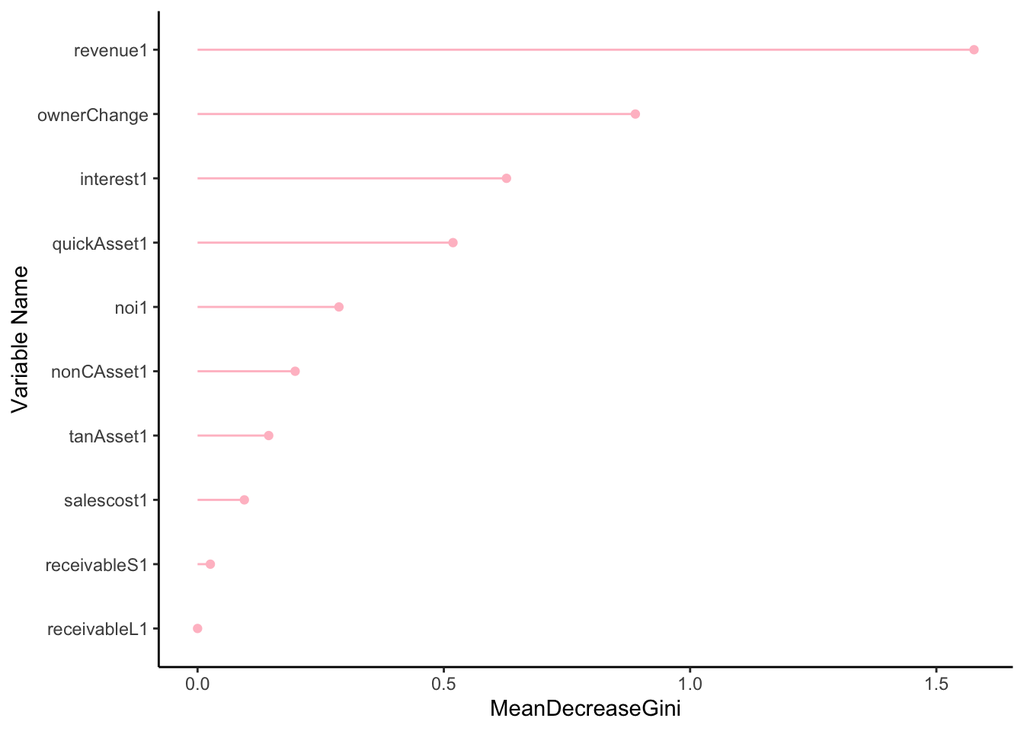

```r
rf_imp <- importance(rf_refit) %>% as.data.frame

ggplot(data=rf_imp,
       mapping=aes(x=reorder(rownames(rf_imp), IncNodePurity), y=IncNodePurity))+
  geom_point(color="pink")+
  geom_segment(aes(x=rownames(rf_imp),xend=rownames(rf_imp),y=0,yend=IncNodePurity), color="pink")+
  labs(x="Variable Name", y="MeanDecreaseGini")+
  coord_flip()+
  theme_classic()
```

varImpPlot()을 이용하였더니 각 변수의 IncNodePurity 값이 출력되었습니다. 이때, IncNodePurity는 각 변수가 전체 예측 결과를 얼마나 향상시키는지를 나타내는 지표로 이해할 수 있습니다. 즉, 우리가 만든 랜덤포레스트 모델에서 차지하는 중요도를 나타내는 값 입니다. 최종 랜덤포레스트 모델을 학습시킬 때 OC ~ revenue1 + salescost1 + noi1 + interest1 + quickAsset1 + receivableS1 + nonCAsset1 + tanAsset1 + receivableL1 + ownerChange를 변수의 조합으로 사용하였습니다. ggplot을 이용한 각 변수의 중요도를 보았을 때, 이 모델에서는 revenue1이 가장 큰 중요도를 차지하고, receivableL1이 가장 낮은 중요도를 가짐을 알 수 있습니다.

## Chapter 3. 회귀모델

### 문제 1. Boston 데이터를 8:2로 train과 test set으로 나누기

```r
library(MASS)
# library(caret)
# library(MLmetrics)
# library(randomForest)
```

- caret 패키지의 createDataPartition()을 이용하여 train과 test set을 나눕니다.
- 타겟변수는 medv이며, p=0.2로 설정합니다 .

```r
data <- Boston
train_idx <- createDataPartition(data$medv, p=0.2, list=FALSE)
train_data <- data[-train_idx,]
valid_data <- data[train_idx,]
```

### 문제 2. expand.grid()를 이용라여 데이터 프레임 만들기

```r
RMSE_rf <- expand.grid(mtry=3:5, ntree=c(10,100,200), RMSE=NA); RMSE_rf
```

```
##   mtry ntree RMSE
## 1    3    10   NA
## 2    4    10   NA
## 3    5    10   NA
## 4    3   100   NA
## 5    4   100   NA
## 6    5   100   NA
## 7    3   200   NA
## 8    4   200   NA
## 9    5   200   NA
```

### 문제 3. medv를 종속변수로 하는 랜덤포레스트에 대한 5-fold 그리드서치 진행, RMSE_rf의 RMSE변수에 해당 RMSE값 넣기

```r
set.seed(1234)

num <- vector(mode="numeric", length=5)

for (i in 1:9){
  for (j in 1:5){
    folds <-createFolds(train_data$medv, k=5, list=TRUE)
    test_idx<-folds[[j]]
    cv_train_data <- train_data[-test_idx,]
    cv_test_data <- train_data[test_idx,]
    rf_fit <- randomForest(medv~., data=cv_train_data, ntree=RMSE_rf[i,2], mtry=RMSE_rf[i,1])
    prediction <- predict(rf_fit,cv_test_data)
    num[j]<-RMSE(prediction, cv_test_data$medv)
  }
  RMSE_rf$RMSE[i]<-mean(num)
}

RMSE_rf
```

```
##   mtry ntree     RMSE
## 1    3    10 3.478870
## 2    4    10 3.503139
## 3    5    10 3.793797
## 4    3   100 3.766243
## 5    4   100 3.657357
## 6    5   100 3.692702
## 7    3   200 3.447691
## 8    4   200 3.262562
## 9    5   200 4.022249
```

### 문제 4. RMSE_rf에서 가장 낮은 RMSE값을 가진 행 출력

```r
RMSE_rf[which.min(RMSE_rf$RMSE), ]
```

```
##   mtry ntree     RMSE
## 8    4   200 3.262562
```

```r
set.seed(1234)

rf_refit <- randomForest(medv~., data=valid_data, mtry=5, ntree=100)

prediction <- predict(rf_refit, valid_data)
RMSE(valid_data$medv, prediction)
```

```
## [1] 1.806836
```